# PRAW: Scraping de Reddit con API

En este breve proyecto se va a hacer scraping de un subconjunto de subforos de Reddit mediante API. Para ello se emplea python y el paquete PRAW.

```python
import praw as praw
import pandas as pd
import datetime as dt
#from ipywidgets import interact, interactive, fixed, interact_manual

from datetime import date

today = date.today()
print("Today's date:", today)

def get_date(date):
    return dt.datetime.fromtimestamp(date)
```

```
Today's date: 2021-05-23
```

Cargamos un .csv genérico y lo renombramos con la fecha de hoy.

```python
dataF = pd.read_csv('sample.csv') #,skiprows=4
dataF.to_csv(str(today)+'.csv', index=False)
```

Ahora hay que establecer conexión con el sitio web via API. Para ello se emplean las credenciales obtenidas tras el registro en la misma.

```python
reddit = praw.Reddit(
    client_id="************",
    client_secret="***************",
    user_agent="**********",
    username='*********',
    password='********')
```

Seleccionamos los subreddits a scrapear añadiéndolos a **subr** y procedemos con el scraping. Primero ordenaremos los subreddit por *hot*

```python
#def pick(subscrap):
subr=['All','worldnews','lifeprotips','getmotivated','dataisbeautiful','politics',
      'programming',"learnmachinelearning","statistics","datacleaning","datascience",
      "datasets","learnpython","deeplearning","analytics","visualization","rstats"]

i=0
while i < len(subr):
    inputSub = subr[i]


    sub = reddit.subreddit(inputSub)

    postDF = {
        "title": [], "url": [], "body": [], "date":[], "score":[],"scraper":[],
        "id":[],"comms_num":[],"subreddit":[], "domain":[], "fecha":[],
    }

    for post in sub.hot(limit=2000):
        postDF["title"].append(post.title)
        postDF["scraper"].append(subr[i])
        postDF["subreddit"].append(subr[i])
        postDF["score"].append(post.score)
        postDF["id"].append(post.id)
        postDF["url"].append(post.url)
        postDF["comms_num"].append(post.num_comments)
        postDF["date"].append(post.created_utc)
        postDF["body"].append(post.selftext)
        postDF["domain"].append(post.domain)
        postDF["fecha"].append(today)


    postDF = pd.DataFrame(postDF)
#   print(postData)
    postDF.to_csv('test.csv', index=False)
    data = pd.read_csv('test.csv') #,skiprows=4
    dataF = pd.read_csv(str(today)+'.csv') #,skiprows=4
    dataFinal=pd.concat([data,dataF]).drop_duplicates(subset=['id', 'scraper'], keep="last").reset_index(drop=True)
    dataFinal.to_csv(str(today)+'.csv', index=False)
    print('The subreddit',subr[i],'has been scraped and merged correctly.')
    i=i+1

print('-------------------------------')
print('Scraping completed.')
#interact(pick, subscrap=['All','worldnews','lifeprotips','getmotivated','dataisbeautiful','politics','programming',"learnmachinelearning","statistics","datacleaning","datascience"]);
```

```
The subreddit All has been scraped and merged correctly.
The subreddit worldnews has been scraped and merged correctly.
The subreddit lifeprotips has been scraped and merged correctly.
The subreddit getmotivated has been scraped and merged correctly.
The subreddit dataisbeautiful has been scraped and merged correctly.
The subreddit politics has been scraped and merged correctly.
The subreddit programming has been scraped and merged correctly.
The subreddit learnmachinelearning has been scraped and merged correctly.
The subreddit statistics has been scraped and merged correctly.
The subreddit datacleaning has been scraped and merged correctly.
The subreddit datascience has been scraped and merged correctly.
The subreddit datasets has been scraped and merged correctly.
The subreddit learnpython has been scraped and merged correctly.
The subreddit deeplearning has been scraped and merged correctly.
The subreddit analytics has been scraped and merged correctly.
The subreddit visualization has been scraped and merged correctly.
The subreddit rstats has been scraped and merged correctly.
-------------------------------
Scraping completed.
```

Se obtiene un fichero .csv de nombre la fecha de creación del mismo. Así mismo se ha incluido código que permite que no se almacenen duplicados.

Hacemos un nuevo scraping, esta vez ordenando los resultados por *new*

```python
#def pick(subscrap):
subr=['All','worldnews','lifeprotips','getmotivated','dataisbeautiful','politics',
      'programming',"learnmachinelearning","statistics","datacleaning","datascience",
      "datasets","learnpython","deeplearning","analytics","visualization","rstats"]

i=0
while i < len(subr):
    inputSub = subr[i]


    sub = reddit.subreddit(inputSub)

    postDF = {
        "title": [], "url": [], "body": [], "date":[], "score":[],"scraper":[],
        "id":[],"comms_num":[],"subreddit":[], "domain":[], "fecha":[],
    }

    for post in sub.new(limit=2000):
        postDF["title"].append(post.title)
        postDF["scraper"].append(subr[i])
        postDF["subreddit"].append(subr[i])
        postDF["score"].append(post.score)
        postDF["id"].append(post.id)
        postDF["url"].append(post.url)
        postDF["comms_num"].append(post.num_comments)
        postDF["date"].append(post.created_utc)
        postDF["body"].append(post.selftext)
        postDF["domain"].append(post.domain)
        postDF["fecha"].append(today)

    postDF = pd.DataFrame(postDF)
#   print(postData)
    postDF.to_csv('test.csv', index=False)
    data = pd.read_csv('test.csv') #,skiprows=4
    dataF = pd.read_csv(str(today)+'.csv') #,skiprows=4
    dataFinal=pd.concat([data,dataF]).drop_duplicates(subset=['id', 'scraper'], keep="last").reset_index(drop=True)
    dataFinal.to_csv(str(today)+'.csv', index=False)
    print('The subreddit',subr[i],'has been scraped and merged correctly.')
    i=i+1

print('-------------------------------')
print('Scraping completed.')
#interact(pick, subscrap=['All','worldnews','lifeprotips','getmotivated','dataisbeautiful','politics','programming',"learnmachinelearning","statistics","datacleaning","datascience"]);
```

```
The subreddit All has been scraped and merged correctly.
The subreddit worldnews has been scraped and merged correctly.
The subreddit lifeprotips has been scraped and merged correctly.
The subreddit getmotivated has been scraped and merged correctly.
The subreddit dataisbeautiful has been scraped and merged correctly.
The subreddit politics has been scraped and merged correctly.
The subreddit programming has been scraped and merged correctly.
The subreddit learnmachinelearning has been scraped and merged correctly.
The subreddit statistics has been scraped and merged correctly.
The subreddit datacleaning has been scraped and merged correctly.
The subreddit datascience has been scraped and merged correctly.
The subreddit datasets has been scraped and merged correctly.
The subreddit learnpython has been scraped and merged correctly.
The subreddit deeplearning has been scraped and merged correctly.
The subreddit analytics has been scraped and merged correctly.
The subreddit visualization has been scraped and merged correctly.
The subreddit rstats has been scraped and merged correctly.
-------------------------------
Scraping completed.
```

Comprobamos el número de subreddits que se han scrapeado

```python
len(subr)
```

```
17
```

## Merge with final .csv

Con este proyecto se obtiene un .csv cada día que se ejecute el script. Conviene tener todos estos datos aunados en un mismo .csv

```python
dataFinal
```

|  | title | url | body | date | score | scraper | id | comms_num | subreddit | domain | fecha |
| --- | --- | --- | --- | --- | --- | --- | --- | --- | --- | --- | --- |
| 0 | how can i get ggplot to display bars with the ... | https://www.reddit.com/r/rstats/comments/lizz6... | hello, my code is\n\n\nggplot(data=data,aes(x=... | 1.613221e+09 | 2 | rstats | lizz64 | 4 | rstats | self.rstats | 2021-05-23 |
| 1 | Cbind dataframes with different number of rows | https://www.reddit.com/r/rstats/comments/liyw4... | Hi everyone\nI'm trying to Cbind two datafram... | 1.613216e+09 | 5 | rstats | liyw4y | 11 | rstats | self.rstats | 2021-05-23 |
| 2 | Since 2015, a third of the world's countries h... | https://i.redd.it/35hgqwy1p3z61.jpg | NaN | 1.621349e+09 | 1 | visualization | nfcimu | 1 | visualization | i.redd.it | 2021-05-23 |
| 3 | How to create an animated bar chart race just ... | https://v.redd.it/yttbx7no2n451 | NaN | 1.592037e+09 | 2 | visualization | h83p4n | 6 | visualization | v.redd.it | 2021-05-23 |
| 4 | How to show line up ranking of all the countri... | https://v.redd.it/hnfi2vj51n451 | NaN | 1.592037e+09 | 1 | visualization | h83l8k | 1 | visualization | v.redd.it | 2021-05-23 |
| ... | ... | ... | ... | ... | ... | ... | ... | ... | ... | ... | ... |
| 16813 | Zhurong rover is now on the ground | https://www.reddit.com/gallery/nigxeq | NaN | 1.621684e+09 | 8845 | All | nigxeq | 662 | All | reddit.com | 2021-05-23 |
| 16814 | Bible. | https://i.redd.it/q7egegw0sr071.jpg | NaN | 1.621732e+09 | 371 | All | niwn9j | 49 | All | i.redd.it | 2021-05-23 |
| 16815 | Shadow me, lose the dress | https://www.reddit.com/r/pettyrevenge/comments... | Years ago, I was browsing through a rack of sh... | 1.621697e+09 | 3646 | All | nikygf | 100 | All | self.pettyrevenge | 2021-05-23 |
| 16816 | TIL that in 1837 a British man sued a woman wh... | https://en.wikipedia.org/wiki/Saverland_v_Newton | NaN | 1.617130e+09 | 24288 | All | mgn3z5 | 415 | All | en.wikipedia.org | 2021-03-30 |
| 16817 | My mate took a photo of a soap bubble and it i... | https://i.redd.it/yenfufydh7q61.jpg | NaN | 1.617128e+09 | 56045 | All | mgm4zp | 819 | All | i.redd.it | 2021-03-30 |

16818 rows × 11 columns

```python
real_data = pd.DataFrame(dataFinal)

datefix = real_data["date"].apply(get_date)

real_data = real_data.assign(date = datefix)

real_data

dataRM=pd.read_csv('RedditMIND.csv') #,skiprows=4
dataRM=pd.concat([real_data,dataRM]).drop_duplicates(subset=['id', 'scraper'], keep="last").reset_index(drop=True)
dataRM.to_csv('RedditMIND.csv', index=False)
```

Se almacena en RedditMIND.csv el dataframe **dataRM** que contiene todos los datos scrapeados, sin duplicados.

```python
dataRM
```

|  | title | url | body | date | score | scraper | id | comms_num | subreddit | domain | fecha |
| --- | --- | --- | --- | --- | --- | --- | --- | --- | --- | --- | --- |
| 0 | Since 2015, a third of the world's countries h... | https://i.redd.it/35hgqwy1p3z61.jpg | NaN | 2021-05-18 07:44:27 | 1 | visualization | nfcimu | 1 | visualization | i.redd.it | 2021-05-23 |
| 1 | StyleGAN2 implementation with side-by-side notes | https://www.reddit.com/r/deeplearning/comments... | Implemented StyleGAN2 model and training loop ... | 2021-05-23 02:53:13 | 1 | deeplearning | nj4ke2 | 0 | deeplearning | self.deeplearning | 2021-05-23 |
| 2 | am learning python programing for knowledge no... | https://www.reddit.com/r/learnpython/comments/... | w | 2021-05-16 09:41:30 | 0 | learnpython | nds94c | 5 | learnpython | self.learnpython | 2021-05-23 |
| 3 | help Vs ? Commands | https://www.reddit.com/r/learnpython/comments/... | I am learning python through an online course ... | 2021-05-16 05:29:27 | 1 | learnpython | ndnbjt | 3 | learnpython | self.learnpython | 2021-05-23 |
| 4 | Audio Classification using Recurrent Neural Ne... | https://www.reddit.com/r/learnpython/comments/... | \nHi! I am looking for someone who has a knowl... | 2021-05-16 05:25:03 | 1 | learnpython | ndn8y1 | 0 | learnpython | self.learnpython | 2021-05-23 |
| ... | ... | ... | ... | ... | ... | ... | ... | ... | ... | ... | ... |
| 60601 | Fun and cool trick | https://i.redd.it/w6xsnw5ckep61.jpg | NaN | 2021-03-27 01:53:10 | 23823 | All | mdszk4 | 143 | All | i.redd.it | 2021-03-27 |
| 60602 | Ryan Higa's apology after being unbanned | https://clips.twitch.tv/PatientChillyWombatTTo... | NaN | 2021-03-27 01:39:50 | 8477 | All | mdspbi | 370 | All | clips.twitch.tv | 2021-03-27 |
| 60603 | Don’t listen to others. it’s your taste. | https://i.redd.it/ty2l4unepfp61.jpg | NaN | 2021-03-27 05:43:21 | 10142 | All | mdxzhl | 250 | All | i.redd.it | 2021-03-27 |
| 60604 | I made a tutorial on using R functions as nati... | https://youtu.be/jyGwOrKTPRY | NaN | 2021-03-26 23:07:05 | 67 | rstats | mdpfgo | 4 | rstats | youtu.be | 2021-03-27 |
| 60605 | [Article] Wisdom of the gods | https://www.musonius.org/letters/wisdom-of-the... | NaN | 2021-03-24 20:13:27 | 3 | getmotivated | mc34me | 1 | getmotivated | musonius.org | 2021-03-27 |

60606 rows × 11 columns

## Dataviz

```python
DD_data=dataRM
```

```python
# Load Plotting libraries
import matplotlib.pyplot as plt # Plotting tool
from matplotlib import cm  # Color palette
import seaborn as sns # Plotting templates, needs plt
```

Convertimos la fecha a un formato que permita trabajar con ella

```python
DD_data['date_short'] = pd.to_datetime(DD_data.date).dt.strftime('%d/%m/%Y')
DD_data.set_index('date',inplace=True)
```

```python
DD_data.info
```

```
<bound method DataFrame.info of                                                                  title  \
date
2021-05-18 07:44:27  Since 2015, a third of the world's countries h...
2021-05-23 02:53:13   StyleGAN2 implementation with side-by-side notes
2021-05-16 09:41:30  am learning python programing for knowledge no...
2021-05-16 05:29:27                                 help Vs ? Commands
2021-05-16 05:25:03  Audio Classification using Recurrent Neural Ne...
...                                                                ...
2021-03-27 01:53:10                                 Fun and cool trick
2021-03-27 01:39:50           Ryan Higa's apology after being unbanned
2021-03-27 05:43:21           Don’t listen to others. it’s your taste.
2021-03-26 23:07:05  I made a tutorial on using R functions as nati...
2021-03-24 20:13:27                       [Article] Wisdom of the gods

                                                                   url  \
date
2021-05-18 07:44:27                https://i.redd.it/35hgqwy1p3z61.jpg
2021-05-23 02:53:13  https://www.reddit.com/r/deeplearning/comments...
2021-05-16 09:41:30  https://www.reddit.com/r/learnpython/comments/...
2021-05-16 05:29:27  https://www.reddit.com/r/learnpython/comments/...
2021-05-16 05:25:03  https://www.reddit.com/r/learnpython/comments/...
...                                                                ...
2021-03-27 01:53:10                https://i.redd.it/w6xsnw5ckep61.jpg
2021-03-27 01:39:50  https://clips.twitch.tv/PatientChillyWombatTTo...
2021-03-27 05:43:21                https://i.redd.it/ty2l4unepfp61.jpg
2021-03-26 23:07:05                       https://youtu.be/jyGwOrKTPRY
2021-03-24 20:13:27  https://www.musonius.org/letters/wisdom-of-the...

                                                                  body  score  \
date
2021-05-18 07:44:27                                                NaN      1
2021-05-23 02:53:13  Implemented StyleGAN2 model and training loop ...      1
2021-05-16 09:41:30                                                  w      0
2021-05-16 05:29:27  I am learning python through an online course ...      1
2021-05-16 05:25:03  \nHi! I am looking for someone who has a knowl...      1
...                                                                ...    ...
2021-03-27 01:53:10                                                NaN  23823
2021-03-27 01:39:50                                                NaN   8477
2021-03-27 05:43:21                                                NaN  10142
2021-03-26 23:07:05                                                NaN     67
```

[output cut: 16 more lines]

```
                                domain       fecha  date_short
date
2021-05-18 07:44:27          i.redd.it  2021-05-23  18/05/2021
2021-05-23 02:53:13  self.deeplearning  2021-05-23  23/05/2021
2021-05-16 09:41:30   self.learnpython  2021-05-23  16/05/2021
2021-05-16 05:29:27   self.learnpython  2021-05-23  16/05/2021
2021-05-16 05:25:03   self.learnpython  2021-05-23  16/05/2021
...                                ...         ...         ...
2021-03-27 01:53:10          i.redd.it  2021-03-27  27/03/2021
2021-03-27 01:39:50    clips.twitch.tv  2021-03-27  27/03/2021
2021-03-27 05:43:21          i.redd.it  2021-03-27  27/03/2021
2021-03-26 23:07:05           youtu.be  2021-03-27  26/03/2021
2021-03-24 20:13:27       musonius.org  2021-03-27  24/03/2021

[60606 rows x 11 columns]>
```

```python
# Start with loading all necessary libraries
import numpy as np
import pandas as pd
from os import path
from PIL import Image
from wordcloud import WordCloud, STOPWORDS, ImageColorGenerator

import matplotlib.pyplot as plt
```

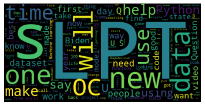

```python
# Start with one review:
text = " ".join(posts for posts in DD_data.title)
stopwords = set(STOPWORDS)
stopwords.update(["DD","play","image"])

# Create and generate a word cloud image:
wordcloud = WordCloud(stopwords=stopwords).generate(text)

# Display the generated image:
plt.imshow(wordcloud, interpolation='bilinear')
plt.axis("off")
plt.savefig(str(today)+'.png')
plt.show()
```

## exploratory analysis

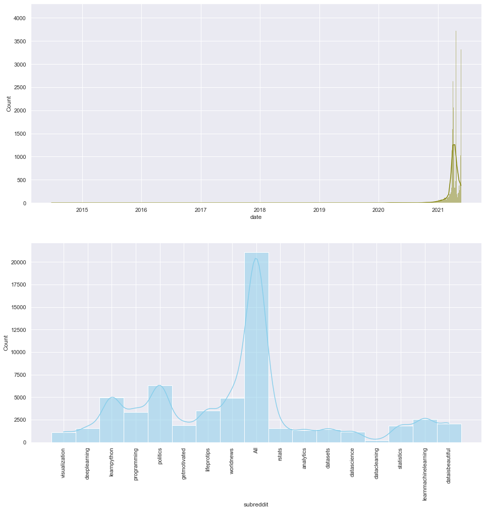

```python
sns.set(style="darkgrid")
df = DD_data

fig, axs = plt.subplots(2, figsize=(16, 16))

sns.histplot(data=df, x="subreddit", kde=True, color="skyblue", ax=axs[1])
sns.histplot(data=df, x="date", kde=True, color="olive", ax=axs[0])
plt.xticks(rotation=90)
plt.show()
```

[figure not shown]

### #Pending: Export data to BigQuery